# Data Challenge 2

## Understanding the Factors Causing Premature Birth in Babies Born with Congenital Anomalies

## Introduction

A premature birth is a birth that occurs before 37 weeks of pregnancy. Pregnancies typically last about 40 weeks. Babies that are born prematurely have a higher risk of death, as they account "for about 17% of infant deaths" (CDC, 2020). Of the surviving prematurely born babies, they may have problems with breathing, feeding difficulties, developmental delay, and more. Some factors that put women at risk of having a premature birth are age - as those who are younger than 16 or older than 35 have a higher chance, being African American, drug use/illness, and other socioeconomic/demographic factors.

A congenital anomaly, also known as a birth defect, "can be defined as structural or functional anomalies that occur during intrauterine life and can be identified prenatally, at birth, or sometimes may only be detected later in infancy" (WHO, 2020). Similar to premature births, there are known risk factors that put babies at a higher chance of being born with a congenital anomaly. Some of those factors include: socioeconomic/demographic factors, illness/drug-use, or maternal nutrional status. It is known that babies that are born with birth defects have an increased risk of premature birth.

For this analysis, I want to look into how great of a role these factors are playing in whether or not a baby with a congenital anomaly is born prematurely or not. In order to do so, I will be utilizing the [2015 Natality Data provided by the National Vital Statistics System](https://www.cdc.gov/nchs/data_access/vitalstatsonline.htm). This data is compiled through the cooperation between the National Center for Health Statistics and the States.

I will be focusing on the observations where a baby was born with a congenital anomaly.

The key factors I will be looking into will be:

- MAGER14 - Recode of the mother's age. Splits age into categories for under 15 years, each year for teenagers, and then groups age by 5 year periods up until 54 years old.
- MBSTATE_REC - Mother's nativity. Provides whether or not the mother was born in the United States.
- MRACE6 - Recode of the mother's race. Splits race into categories for White, Black, Asian Indian, Asian, Pacific Islander, or more than one race.
- PRECARE5 - Month prenatal care began recode.
- PREVIS_REC - Number of Prenatal Visits Recode. Splits number of visits into categorical features.
- CIG_REC - Cigarette Recode. Whether or not mother smoked during pregnancy.
- BMI_R - Body mass index recode. Splits mother's BMI into categories of underweight, normal, overweight, obese, and so on.
- DPLURAL - Plurality Recode. Categorical feature of how many babies were born in one pregnancy.
- DBWTLBS - Birth weight in pounds.
- DMETH_REC - Delivery Method Recode.
- SEX - Sex of the baby.

Of these variables, `DBWT` is the only numeric variable.

The target variable for this analysis will be **BORN_PRE**, a modified version of **OEGest_R3**, which is a categorical variable that provides whether or not a baby was born prematurely (under 37 weeks) or not.

The importance for this analysis is for readers to understand how different environmental/socioeconomic/demographic factors can effect the chance of a baby with a congenital anomaly being born prematurely. With the understanding of how each of these factors can play a role in whether or not a baby is born prematurely, a mother can take preventitive steps to avoid premature births given their baby is being born with a congenital anomaly.

## Data Loading

```sas
options nosource nonotes errors=0;

filename nat1 url "https://uofi.box.com/shared/static/gb07nz7jafspk65wzxq6awlu02kypiq7.csv" termstr=crlf;
filename nat2 url "https://uofi.box.com/shared/static/kr2s5wp3jpxdlpcjmq2qs15oo4797u4y.csv" termstr=crlf;
filename nat3 url "https://uofi.box.com/shared/static/hwsoobqngb8zfyjbwxvmrejjz1lg3yeh.csv" termstr=crlf;
filename nat4 url "https://uofi.box.com/shared/static/omxbqyr1a74w3es75h2f8ihrft8ebipi.csv" termstr=crlf;
filename nat5 url "https://uofi.box.com/shared/static/bkbxdr64tqbv9016cftku1mduot8sqdp.csv" termstr=crlf;
filename nat6 url "https://uofi.box.com/shared/static/cm2g1ltu6mo0tib7tko7i1ek4yt23qb3.csv" termstr=crlf;
filename nat7 url "https://uofi.box.com/shared/static/fggxentxllv9c2vqlziuxegezb4sru0a.csv" termstr=crlf;
filename nat8 url "https://uofi.box.com/shared/static/1dcgq9a80l4s30kng1wtt8blasoeye4s.csv" termstr=crlf;
filename nat9 url "https://uofi.box.com/shared/static/44aowyv5hrg1k2j8d0vyr81wusuealpg.csv" termstr=crlf;
filename nat10 url "https://uofi.box.com/shared/static/xf7r94alpzaqv4wxh5liqw7rpk21wb6l.csv" termstr=crlf;
filename nat11 url "https://uofi.box.com/shared/static/fqz253x7a3rp2koo7ao5hkjhfg9ge0sf.csv" termstr=crlf;
filename nat12 url "https://uofi.box.com/shared/static/sajmr45u3anodk4jv8fotn5c8rxfyoel.csv" termstr=crlf;
filename nat13 url "https://uofi.box.com/shared/static/qs562goaxf52fu9tq8lzu15869m1exja.csv" termstr=crlf;
filename nat14 url "https://uofi.box.com/shared/static/o797c0aokik20t3ki36pkxgo93zicbew.csv" termstr=crlf;
filename nat15 url "https://uofi.box.com/shared/static/k0oo6r8h4sdgv5nj3fnceuici4eisne2.csv" termstr=crlf;
filename nat16 url "https://uofi.box.com/shared/static/8dtro93h20zqpddr6hg6z0qwrjnzk93z.csv" termstr=crlf;
filename nat17 url "https://uofi.box.com/shared/static/jx3nrjnfqnt4v45lvmyrz970fl1d3wqq.csv" termstr=crlf;
filename nat18 url "https://uofi.box.com/shared/static/9lo5hzr82n6t1a21fekgar69yixq6rc2.csv" termstr=crlf;
filename nat19 url "https://uofi.box.com/shared/static/3cgizozuz8afe7gduy6r5phwou3nrxz1.csv" termstr=crlf;
filename nat20 url "https://uofi.box.com/shared/static/eq9k4d73ansal5p8mspu3mpslmzs7x8g.csv" termstr=crlf;

proc import datafile=nat1 out=birth01(keep = DPLURAL CA_ANEN CA_MNSB CA_CCHD
                                            CA_CDH CA_OMPH CA_GAST CA_LIMB CA_CLEFT
                                            CA_CLPAL CA_DOWN CA_DISOR CA_HYPO
                                            OEGest_R3 SEX MAGER14 MBSTATE_REC MRACE6 PRECARE5
                                            PREVIS_REC CIG_REC BMI_R DBWT DMETH_REC) replace dbms=csv;
run;

proc import datafile=nat2 out=birth02(keep = DPLURAL CA_ANEN CA_MNSB CA_CCHD
                                            CA_CDH CA_OMPH CA_GAST CA_LIMB CA_CLEFT
                                            CA_CLPAL CA_DOWN CA_DISOR CA_HYPO
                                            OEGest_R3 SEX MAGER14 MBSTATE_REC MRACE6 PRECARE5
                                            PREVIS_REC CIG_REC BMI_R DBWT DMETH_REC) replace dbms=csv;
run;

proc import datafile=nat3 out=birth03(keep = DPLURAL CA_ANEN CA_MNSB CA_CCHD
                                            CA_CDH CA_OMPH CA_GAST CA_LIMB CA_CLEFT
                                            CA_CLPAL CA_DOWN CA_DISOR CA_HYPO
                                            OEGest_R3 SEX MAGER14 MBSTATE_REC MRACE6 PRECARE5
                                            PREVIS_REC CIG_REC BMI_R DBWT DMETH_REC) replace dbms=csv;
run;

proc import datafile=nat4 out=birth04(keep = DPLURAL CA_ANEN CA_MNSB CA_CCHD
                                            CA_CDH CA_OMPH CA_GAST CA_LIMB CA_CLEFT
                                            CA_CLPAL CA_DOWN CA_DISOR CA_HYPO
                                            OEGest_R3 SEX MAGER14 MBSTATE_REC MRACE6 PRECARE5
                                            PREVIS_REC CIG_REC BMI_R DBWT DMETH_REC) replace dbms=csv;
run;

proc import datafile=nat5 out=birth05(keep = DPLURAL CA_ANEN CA_MNSB CA_CCHD
                                            CA_CDH CA_OMPH CA_GAST CA_LIMB CA_CLEFT
                                            CA_CLPAL CA_DOWN CA_DISOR CA_HYPO
                                            OEGest_R3 SEX MAGER14 MBSTATE_REC MRACE6 PRECARE5
                                            PREVIS_REC CIG_REC BMI_R DBWT DMETH_REC) replace dbms=csv;
run;

proc import datafile=nat6 out=birth06(keep = DPLURAL CA_ANEN CA_MNSB CA_CCHD
                                            CA_CDH CA_OMPH CA_GAST CA_LIMB CA_CLEFT
                                            CA_CLPAL CA_DOWN CA_DISOR CA_HYPO
                                            OEGest_R3 SEX MAGER14 MBSTATE_REC MRACE6 PRECARE5
                                            PREVIS_REC CIG_REC BMI_R DBWT DMETH_REC) replace dbms=csv;
run;

proc import datafile=nat7 out=birth07(keep = DPLURAL CA_ANEN CA_MNSB CA_CCHD
                                            CA_CDH CA_OMPH CA_GAST CA_LIMB CA_CLEFT
                                            CA_CLPAL CA_DOWN CA_DISOR CA_HYPO
                                            OEGest_R3 SEX MAGER14 MBSTATE_REC MRACE6 PRECARE5
                                            PREVIS_REC CIG_REC BMI_R DBWT DMETH_REC) replace dbms=csv;
run;

proc import datafile=nat8 out=birth08(keep = DPLURAL CA_ANEN CA_MNSB CA_CCHD
                                            CA_CDH CA_OMPH CA_GAST CA_LIMB CA_CLEFT
                                            CA_CLPAL CA_DOWN CA_DISOR CA_HYPO
                                            OEGest_R3 SEX MAGER14 MBSTATE_REC MRACE6 PRECARE5
                                            PREVIS_REC CIG_REC BMI_R DBWT DMETH_REC) replace dbms=csv;
run;

proc import datafile=nat9 out=birth09(keep = DPLURAL CA_ANEN CA_MNSB CA_CCHD
                                            CA_CDH CA_OMPH CA_GAST CA_LIMB CA_CLEFT
                                            CA_CLPAL CA_DOWN CA_DISOR CA_HYPO
                                            OEGest_R3 SEX MAGER14 MBSTATE_REC MRACE6 PRECARE5
                                            PREVIS_REC CIG_REC BMI_R DBWT DMETH_REC) replace dbms=csv;
run;

proc import datafile=nat10 out=birth10(keep = DPLURAL CA_ANEN CA_MNSB CA_CCHD
                                            CA_CDH CA_OMPH CA_GAST CA_LIMB CA_CLEFT
                                            CA_CLPAL CA_DOWN CA_DISOR CA_HYPO
                                            OEGest_R3 SEX MAGER14 MBSTATE_REC MRACE6 PRECARE5
                                            PREVIS_REC CIG_REC BMI_R DBWT DMETH_REC) replace dbms=csv;
run;

proc import datafile=nat11 out=birth11(keep = DPLURAL CA_ANEN CA_MNSB CA_CCHD
                                            CA_CDH CA_OMPH CA_GAST CA_LIMB CA_CLEFT
                                            CA_CLPAL CA_DOWN CA_DISOR CA_HYPO
                                            OEGest_R3 SEX MAGER14 MBSTATE_REC MRACE6 PRECARE5
                                            PREVIS_REC CIG_REC BMI_R DBWT DMETH_REC) replace dbms=csv;
run;

proc import datafile=nat12 out=birth12(keep = DPLURAL CA_ANEN CA_MNSB CA_CCHD
                                            CA_CDH CA_OMPH CA_GAST CA_LIMB CA_CLEFT
                                            CA_CLPAL CA_DOWN CA_DISOR CA_HYPO
                                            OEGest_R3 SEX MAGER14 MBSTATE_REC MRACE6 PRECARE5
                                            PREVIS_REC CIG_REC BMI_R DBWT DMETH_REC) replace dbms=csv;
run;

proc import datafile=nat13 out=birth13(keep = DPLURAL CA_ANEN CA_MNSB CA_CCHD
                                            CA_CDH CA_OMPH CA_GAST CA_LIMB CA_CLEFT
                                            CA_CLPAL CA_DOWN CA_DISOR CA_HYPO
                                            OEGest_R3 SEX MAGER14 MBSTATE_REC MRACE6 PRECARE5
                                            PREVIS_REC CIG_REC BMI_R DBWT DMETH_REC) replace dbms=csv;
run;

proc import datafile=nat14 out=birth14(keep = DPLURAL CA_ANEN CA_MNSB CA_CCHD
                                            CA_CDH CA_OMPH CA_GAST CA_LIMB CA_CLEFT
                                            CA_CLPAL CA_DOWN CA_DISOR CA_HYPO
                                            OEGest_R3 SEX MAGER14 MBSTATE_REC MRACE6 PRECARE5
                                            PREVIS_REC CIG_REC BMI_R DBWT DMETH_REC) replace dbms=csv;
run;

proc import datafile=nat15 out=birth15(keep = DPLURAL CA_ANEN CA_MNSB CA_CCHD
                                            CA_CDH CA_OMPH CA_GAST CA_LIMB CA_CLEFT
                                            CA_CLPAL CA_DOWN CA_DISOR CA_HYPO
                                            OEGest_R3 SEX MAGER14 MBSTATE_REC MRACE6 PRECARE5
                                            PREVIS_REC CIG_REC BMI_R DBWT DMETH_REC) replace dbms=csv;
run;

proc import datafile=nat16 out=birth16(keep = DPLURAL CA_ANEN CA_MNSB CA_CCHD
                                            CA_CDH CA_OMPH CA_GAST CA_LIMB CA_CLEFT
                                            CA_CLPAL CA_DOWN CA_DISOR CA_HYPO
                                            OEGest_R3 SEX MAGER14 MBSTATE_REC MRACE6 PRECARE5
                                            PREVIS_REC CIG_REC BMI_R DBWT DMETH_REC) replace dbms=csv;
run;

proc import datafile=nat17 out=birth17(keep = DPLURAL CA_ANEN CA_MNSB CA_CCHD
                                            CA_CDH CA_OMPH CA_GAST CA_LIMB CA_CLEFT
                                            CA_CLPAL CA_DOWN CA_DISOR CA_HYPO
                                            OEGest_R3 SEX MAGER14 MBSTATE_REC MRACE6 PRECARE5
                                            PREVIS_REC CIG_REC BMI_R DBWT DMETH_REC) replace dbms=csv;
run;

proc import datafile=nat18 out=birth18(keep = DPLURAL CA_ANEN CA_MNSB CA_CCHD
                                            CA_CDH CA_OMPH CA_GAST CA_LIMB CA_CLEFT
                                            CA_CLPAL CA_DOWN CA_DISOR CA_HYPO
                                            OEGest_R3 SEX MAGER14 MBSTATE_REC MRACE6 PRECARE5
                                            PREVIS_REC CIG_REC BMI_R DBWT DMETH_REC) replace dbms=csv;
run;

proc import datafile=nat19 out=birth19(keep = DPLURAL CA_ANEN CA_MNSB CA_CCHD
                                            CA_CDH CA_OMPH CA_GAST CA_LIMB CA_CLEFT
                                            CA_CLPAL CA_DOWN CA_DISOR CA_HYPO
                                            OEGest_R3 SEX MAGER14 MBSTATE_REC MRACE6 PRECARE5
                                            PREVIS_REC CIG_REC BMI_R DBWT DMETH_REC) replace dbms=csv;
run;

proc import datafile=nat20 out=birth20(keep = DPLURAL CA_ANEN CA_MNSB CA_CCHD
                                            CA_CDH CA_OMPH CA_GAST CA_LIMB CA_CLEFT
                                            CA_CLPAL CA_DOWN CA_DISOR CA_HYPO
                                            OEGest_R3 SEX MAGER14 MBSTATE_REC MRACE6 PRECARE5
                                            PREVIS_REC CIG_REC BMI_R DBWT DMETH_REC) replace dbms=csv;
run;
```

```
SAS Connection established. Subprocess id is 2198
```

[output not shown]

[output cut: 29 more lines]

```


200000 rows created in WORK.BIRTH17 from NAT17.



200000 rows created in WORK.BIRTH18 from NAT18.



200000 rows created in WORK.BIRTH19 from NAT19.



188733 rows created in WORK.BIRTH20 from NAT20.
```

```sas
proc format;
    value preemie_form  1 = 'Yes'
                       0 = 'No';
    value sex_form  1 = 'Male'
                    0 = 'Female';
    value age_form  1 = '< 15 Years'
                    3 = '15 Years'
                    4 = '16 Years'
                    5 = '17 Years'
                    6 = '18 Years'
                    7 = '19 Years'
                    8 = '20-24 Years'
                    9 = '25-29 Years'
                    10 = '30-34 Years'
                    11 = '35-39 Years'
                    12 = '40-44 Years'
                    13 = '45-49 Years'
                    14 = '50-54 Years';
    value nat_form  1 = 'Born in U.S.'
                    2 = 'Born outside U.S.';
    value race_form  1 = 'White'
                     2 = 'Black'
                     3 = 'Asian Indian'
                     4 = 'Asian'
                     5 = 'Pacific Islander'
                     6 = 'Multiracial';
    value precare_form  1 = '1st-3rd Month'
                        2 = '4th-6th Month'
                        3 = '7th-Final Month'
                        4 = 'No Prenatal Care';
    value previs_form  1 = 'No Visits'
                       2 = '1-2 Visits'
                       3 = '3-4 Visits'
                       4 = '5-6 Visits'
                       5 = '7-8 Visits'
                       6 = '9-10 Visits'
                       7 = '11-12 Visits'
                       8 = '13-14 Visits'
                       9 = '15-16 Visits'
                       10 = '17-18 Visits'
                       11 = '19+ Visits';
    value cig_form  0 = 'Did Not Smoke'
                    1 = 'Did Smoke';
    value bmi_form  1 = 'Underweight <18.5'
                    2 = 'Normal 18.5-24.9'
                    3 = 'Overweight 25.0-29.9'
                    4 = 'Obesity I 35.0-34.9'
                    5 = 'Obesity II 35.0-39.9'
                    6 = 'Extreme Obesity III >= 40.0';
    value dmeth_form  1 = 'Vaginal'
                      2 = 'C-Section';
    value cong_form  0 = 'No'
                     1 = 'Yes';
    value dplural_form 1 = 'Single'
                       2 = 'Twin'
                       3 = 'Triplet'
                       4 = 'Quadruplet'
                       5 = 'Quintuplet or higher'
run;
```

```sas
data birth;
    set birth01 birth02 birth03 birth04
        birth05 birth06 birth07 birth08
        birth09 birth10 birth11 birth12
        birth13 birth14 birth15 birth16
        birth17 birth18 birth19 birth20;
    if CA_ANEN='Y' or CA_MNSB='Y' or CA_CCHD='Y' or CA_CDH='Y'
       or CA_OMPH='Y' or CA_GAST='Y' or CA_LIMB='Y' or CA_CLEFT='Y'
       or CA_CLPAL='Y' or CA_DOWN='C' or CA_DISOR='C' or CA_HYPO='Y'
       then CONG_ANOM=1;
    else CONG_ANOM = 0;
    if SEX='M' then SEX_BIN=1;
    else SEX_BIN=0;
    if CIG_REC='Y' then CIG_BIN=1;
    else CIG_BIN=0;
    if OEGest_R3 = 1 then BORN_PRE = 1;
    else BORN_PRE = 0;
    DBWTLBS = DBWT / 454;
    /*remove "NA" values*/
    if OEGest_R3 ne 3 and MBSTATE_REC ne 3 and PREVIS_REC ne 12 and CONG_ANOM ne 0
        and PRECARE5 ne 5 and BMI_R ne 9 and DBWT ne 9999 and DMETH_REC ne 9 and MRACE6 ne 9;
    keep SEX_BIN CIG_BIN BORN_PRE MBSTATE_REC PREVIS_REC
         PRECARE5 BMI_R DBWTLBS DMETH_REC MAGER14 MRACE6 DPLURAL;
run;

options source notes errors=20;
```

[output not shown]

## Analysis

For starters, let's get an idea of the data we are working with. I will print out the first 15 observations of all variables. I will also be applying formats to the variables in order for a more understandable printout of the variables.

```sas
proc print data=birth(obs=15);
    format MAGER14 age_form. MBSTATE_REC nat_form. MRACE6 race_form.
           PRECARE5 precare_form. PREVIS_REC previs_form. BMI_R bmi_form.
           DMETH_REC dmeth_form. BORN_PRE preemie_form. DPLURAL dplural_form.
           SEX_BIN sex_form. CIG_BIN cig_form.;
run;
```

The SAS System

| Obs | MAGER14 | MBSTATE_REC | MRACE6 | PRECARE5 | PREVIS_REC | BMI_R | DMETH_REC | DPLURAL | SEX_BIN | CIG_BIN | BORN_PRE | DBWTLBS |
| --- | --- | --- | --- | --- | --- | --- | --- | --- | --- | --- | --- | --- |
| 1 | 40-44 Years | Born in U.S. | White | 1st-3rd Month | 15-16 Visits | Normal 18.5-24.9 | C-Section | Single | Female | Did Not Smoke | No | 3.78855 |
| 2 | 20-24 Years | Born in U.S. | White | 1st-3rd Month | 9-10 Visits | Normal 18.5-24.9 | Vaginal | Single | Female | Did Not Smoke | No | 7.30617 |
| 3 | 25-29 Years | Born in U.S. | Asian Indian | 1st-3rd Month | 7-8 Visits | Overweight 25.0-29.9 | C-Section | Single | Female | Did Not Smoke | Yes | 4.38326 |
| 4 | 20-24 Years | Born in U.S. | White | 1st-3rd Month | 13-14 Visits | Obesity II 35.0-39.9 | C-Section | Single | Female | Did Not Smoke | No | 7.79736 |
| 5 | 30-34 Years | Born in U.S. | Multiracial | 1st-3rd Month | 11-12 Visits | Normal 18.5-24.9 | C-Section | Single | Male | Did Not Smoke | Yes | 6.93833 |
| 6 | 19 Years | Born in U.S. | Asian Indian | 4th-6th Month | 7-8 Visits | Obesity I 35.0-34.9 | Vaginal | Single | Female | Did Smoke | No | 4.97797 |
| 7 | 20-24 Years | Born outside U.S. | White | 1st-3rd Month | 5-6 Visits | Obesity I 35.0-34.9 | C-Section | Single | Female | Did Not Smoke | Yes | 2.62335 |
| 8 | 30-34 Years | Born in U.S. | Asian Indian | 1st-3rd Month | 9-10 Visits | Overweight 25.0-29.9 | Vaginal | Single | Female | Did Not Smoke | No | 7.97357 |
| 9 | 35-39 Years | Born in U.S. | White | 7th-Final Month | 1-2 Visits | Obesity I 35.0-34.9 | Vaginal | Single | Female | Did Not Smoke | No | 6.43172 |
| 10 | 25-29 Years | Born in U.S. | White | 4th-6th Month | 3-4 Visits | Overweight 25.0-29.9 | Vaginal | Single | Male | Did Not Smoke | No | 6.96916 |
| 11 | 25-29 Years | Born outside U.S. | White | 1st-3rd Month | 7-8 Visits | Overweight 25.0-29.9 | C-Section | Single | Male | Did Not Smoke | No | 7.56828 |
| 12 | 25-29 Years | Born in U.S. | Asian Indian | 1st-3rd Month | 7-8 Visits | Overweight 25.0-29.9 | C-Section | Single | Female | Did Not Smoke | Yes | 5.24229 |
| 13 | 20-24 Years | Born in U.S. | Multiracial | 1st-3rd Month | 11-12 Visits | Overweight 25.0-29.9 | Vaginal | Single | Male | Did Not Smoke | No | 7.22467 |
| 14 | 19 Years | Born in U.S. | White | 1st-3rd Month | 7-8 Visits | Overweight 25.0-29.9 | C-Section | Single | Male | Did Not Smoke | Yes | 6.01322 |
| 15 | 30-34 Years | Born outside U.S. | White | 1st-3rd Month | 5-6 Visits | Obesity I 35.0-34.9 | C-Section | Single | Male | Did Not Smoke | Yes | 2.42291 |

Looking at the data above, we are able to get a better idea of the variables included and their meaning.

I will, however, begin analyzing each individual variable to get a better understanding with it's relationship to whether or not a baby is born with a congenital anomaly.

For categorical variables, I will analyze each by using a grouped bar plot. In order to determine the relationship between the variable and the target variable of whether or not the baby was born prematurely, I will look at the relative frequency percentage of born premature or not between each category. This plot allows me to visualize this relationship in a prettier sense then looking at a frequency table. This plot will contain the same information as frequency table. Any plot that is not obvious in differences between groups will be further analyzed using a chi-square test for independence.

For numerical variables, I will look at the histogram as a whole and histograms between babies born prematurely or not. This will allow me to see the distribution of the variable as well as the distribution between groups. I will also be looking at a numerical summary of the variable for some general statistics, and then two box-plots - one for the whole variable and one grouped one. This will allow me to look for outliers in the variable as well as outliers in each group.

I will begin with the variable **MAGER14**, which as seen above, is the mother's age in a categorical sense.

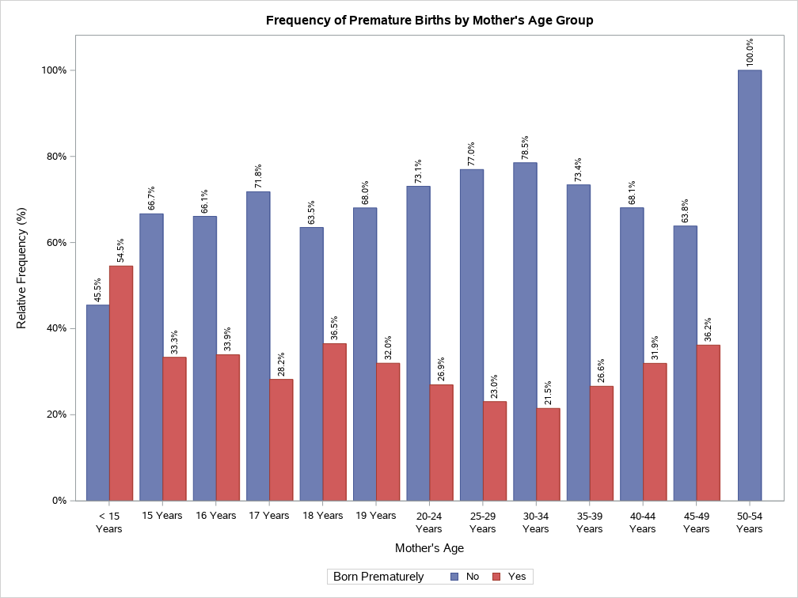

```sas
ods graphics /width=10.5in;

proc sgplot data = birth pctlevel=group;
    format MAGER14 age_form. BORN_PRE cong_form.;
    vbar MAGER14 / group = BORN_PRE stat=percent groupdisplay=cluster datalabel;
    title1 "Frequency of Premature Births by Mother's Age Group";
    label BORN_PRE = "Born Prematurely";
    xaxis label="Mother's Age";
    yaxis label="Relative Frequency (%)";
run;
```

The plot above displays the relative frequency of babies with congenital anomalies born prematurely or not between age groups. Each age group adds up to 100%. This will allow us to better understand if age is playing a role in babies being born prematurely or not.

Looking at the plot, we can see that the age group with the highest percentage of babies being born prematurely are those that are less than 15 years. This is due to the higher chances of those younger than 16 years old being at a higher risk for a premature birth, which is caused by the lack of complete body development of the mother.

The lack of any premature births at mothers that are 50-54 years old tells me that this observation(s) is an outlier in the data.

Overall, this plot tells us that age is definitely a factor in whether or not a baby with a congenital anomaly is born prematurely which can be further confirmed by scientific research.

The next variable to be analyzed is **MBSTATE_REC**, which is a categorical variable that shows if the mother was born inside the United States or not. Note that the being born inside the United States does not include any of it's territories, such as Puerto Rico.

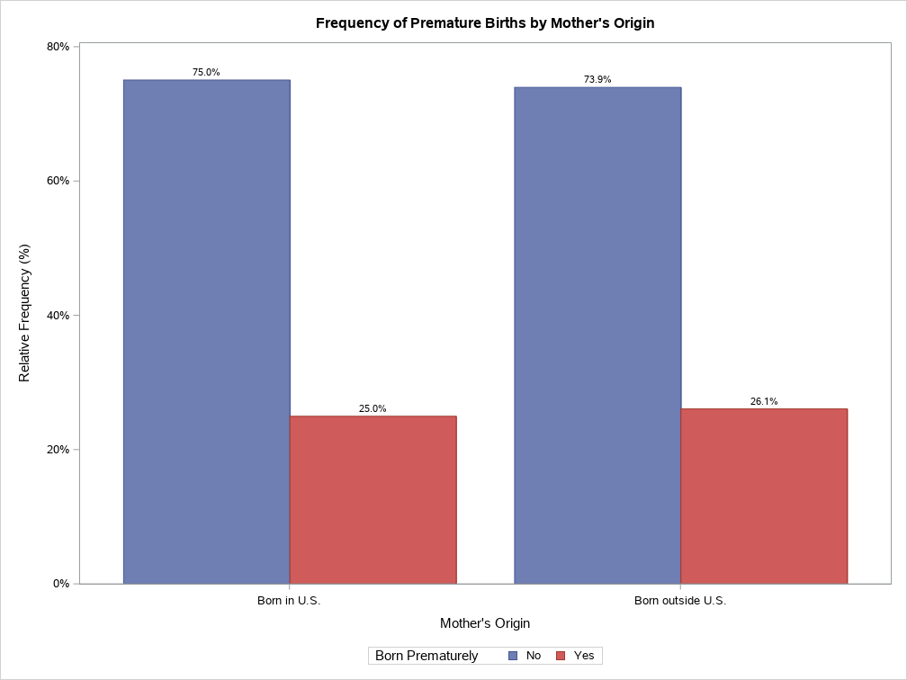

```sas
proc sgplot data = birth pctlevel=group;
    format MBSTATE_REC nat_form. BORN_PRE preemie_form.;
    vbar MBSTATE_REC / group = BORN_PRE stat=percent groupdisplay=cluster datalabel;
    title1 "Frequency of Premature Births by Mother's Origin";
    label BORN_PRE = "Born Prematurely";
    xaxis label="Mother's Origin";
    yaxis label="Relative Frequency (%)";
run;
```

Using the plot above we are able to see right away that when comparing mothers born inside the United States (in any of the 50 states) compared to mothers born outside of the United States, there is not much of a difference between groups.

Mother's born inside the U.S giving birth to a baby with a congenital anomaly, we see that 25.0% of those babies are born prematurely and 75.0% of those babies are not.

Considering mother's born outside of the United States, we see that 26.1% of babies with a congenital anomaly are born prematurely and 73.9% are not.

Overall, there is not a large difference between premature births between the origin of the mother.

With that said, I want to further look into possible association between these two variables using a chi-square test. The hypothesis test for this is: $H_0:$ Being born prematurely is independent of the mother's origin $H_a:$ Being born prematurely is associated with the mother's origin

```sas
proc freq data=birth;
    tables born_pre*MBSTATE_REC /chisq;
    ods select ChiSq;
run;
```

The FREQ Procedure

Statistics for Table of BORN_PRE by MBSTATE_REC

| Statistic | DF | Value | Prob |
| --- | --- | --- | --- |
| Chi-Square | 1 | 0.9754 | 0.3233 |
| Likelihood Ratio Chi-Square | 1 | 0.9694 | 0.3248 |
| Continuity Adj. Chi-Square | 1 | 0.9181 | 0.3380 |
| Mantel-Haenszel Chi-Square | 1 | 0.9754 | 0.3233 |
| Phi Coefficient |  | 0.0095 |  |
| Contingency Coefficient |  | 0.0095 |  |
| Cramer's V |  | 0.0095 |  |

Looking at the output above, we get a p-value of .3233 and therefore fail to reject $H_0$. We cannot say there is any association between these variables, and this is further confirmed by very small values of the Phi & Contingency Coefficient, and Cramer's V. I do believe this variable will not be of much use in modeling, but will be kept in for model selection to decide it's usefulness.

Next variable to analyze is the **MRACE6** variable, which is a categorical variable for the mother's race.

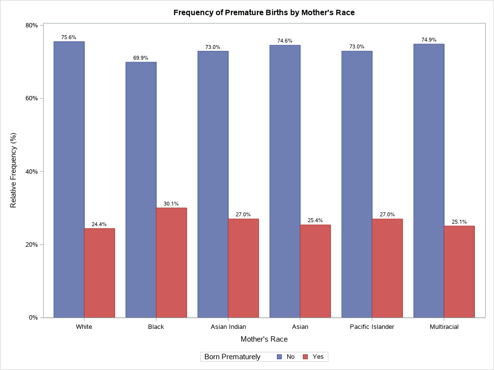

```sas
proc sgplot data = birth pctlevel=group;
    format MRACE6 race_form. BORN_PRE preemie_form.;
    vbar MRACE6 / group = BORN_PRE stat=percent groupdisplay=cluster datalabel;
    title1 "Frequency of Premature Births by Mother's Race";
    label BORN_PRE = "Born Prematurely";
    xaxis label="Mother's Race";
    yaxis label="Relative Frequency (%)";
run;
```

Using the plot above, it can be said that there are small yet noticeable differences of percentage of babies with congenital anomalies being born prematurely when comparing between a mother's race.

The race with the lowest percent of premature births are mothers that are White, with 24.4% of observations being a premature birth.

The race with the highest percent of premature births are mothers that are Black, with 30.1% of observations being a premature birth. While odd, there is research supporting this observation that says that being African American can lead to a higher risk of having a baby born prematurely.

Other races fall between 24.% and 30.1%, and have similar percentages of premature births.

Next to be analyzed is the variable **PRECARE5**. This variable is interesting to me because I believe it will play a pretty sizeable role in whether or not a baby is born with an anomaly. This is due to my understanding that prenatal care is important for giving birth to a healthier baby.

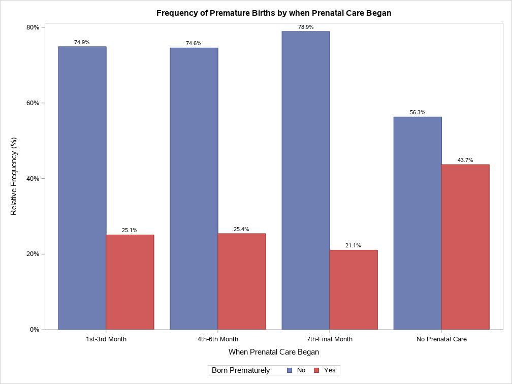

```sas
proc sgplot data = birth pctlevel=group;
    format PRECARE5 precare_form. BORN_PRE preemie_form.;
    vbar PRECARE5 / group = BORN_PRE stat=percent groupdisplay=cluster datalabel;
    title1 "Frequency of Premature Births by when Prenatal Care Began";
    label BORN_PRE = "Born Prematurely";
    xaxis label="When Prenatal Care Began";
    yaxis label="Relative Frequency (%)";
run;
```

Babies born with a congenital anomaly have the highest chance of being born prematurely if no prenatal care was done by the mother, shown by this graph, as 43.7% of mothers who did not have prenatal care resulted in a premature birth.

An odd observation of this graph is that those who began prenatal care in the 7th-final month have the lowest percentage of babies born prematurely. This may be due to outliers in the data or a low percentage of observations in this category.

Not considering 7th-final month, we see an increasing trend of babies born prematurely when looking at when the mother began prenatal care. This confirms my belief that prenatal care is important, and should be something done by the mother to prevent premature birth.

Continuing with prenatal care, I move on to analyze the **PREVIS_REC** variable. This variable is related to the above variable, as **PREVIS_REC** is a categorical variable that tells us how many times a mother had prenatal visits.

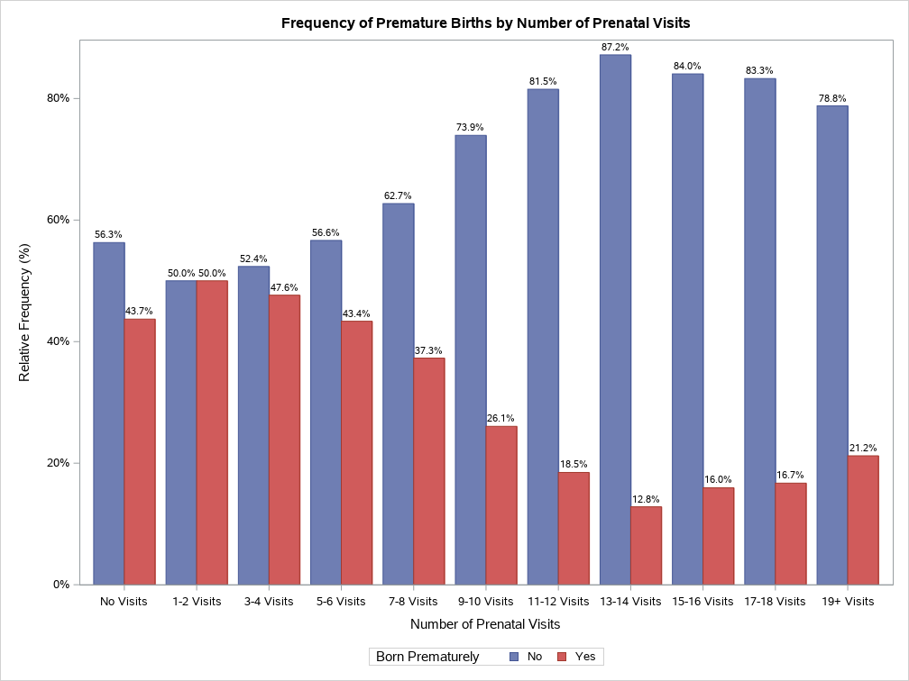

```sas
proc sgplot data = birth pctlevel=group;
    format PREVIS_REC previs_form. BORN_PRE preemie_form.;
    vbar PREVIS_REC / group = BORN_PRE stat=percent groupdisplay=cluster datalabel;
    title1 "Frequency of Premature Births by Number of Prenatal Visits";
    label BORN_PRE = "Born Prematurely";
    xaxis label="Number of Prenatal Visits";
    yaxis label="Relative Frequency (%)";
run;
```

Using the plot above, my belief that prenatal care being important to whether or not a baby is born prematurely is continued to be confirmed above. There is an obvious downward trend of premature births when you increase the number of prenatal visits done by the mother.

It should be noted that after 14 visits, the number of premature births begins to increase again. This could be due to the circumstances of the birth, that result in more required visits due to high complications with the pregnancy. Note that these observations are all babies born with a congenital anomaly, so this option must be considered as these babies all are born with some type of anomaly.

Next variable to be analyzed is **BMI_R**, which is a categorical variable of the mother's BMI (Body Mass Index). My prior belief is that mothers that are either too overweight or too underweight will have a higher chance of premature births due to not being able to provide enough nutrients to the baby.

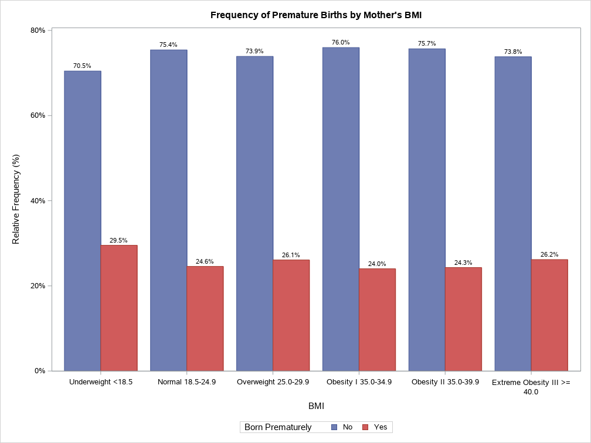

```sas
proc sgplot data = birth pctlevel=group;
    format BMI_R bmi_form. BORN_PRE preemie_form.;
    vbar BMI_R / group = BORN_PRE stat=percent groupdisplay=cluster datalabel;
    title1 "Frequency of Premature Births by Mother's BMI";
    label BORN_PRE = "Born Prematurely";
    xaxis label="BMI";
    yaxis label="Relative Frequency (%)";
run;
```

While the number of premature births between BMI categories do not differ by much, there are definitely some small noticeable differences. Confirming my prior beliefs, the groups with the highest chance of a premature birth are those that are Underweight and Extremely Obese (29.5% and 26.2%, respectively).

Overall, it can be said that there is some difference between BMI's that can definitely contribute to whether or not a baby with a congenital anomaly is born prematurely. To confirm this, I will utilize a chi-square test for independence.

```sas
proc freq data=birth;
    tables born_pre*BMI_R /chisq;
    ods select ChiSq;
run;
```

The FREQ Procedure

Statistics for Table of BORN_PRE by BMI_R

| Statistic | DF | Value | Prob |
| --- | --- | --- | --- |
| Chi-Square | 5 | 8.1895 | 0.1461 |
| Likelihood Ratio Chi-Square | 5 | 8.0391 | 0.1541 |
| Mantel-Haenszel Chi-Square | 1 | 0.1566 | 0.6923 |
| Phi Coefficient |  | 0.0276 |  |
| Contingency Coefficient |  | 0.0275 |  |
| Cramer's V |  | 0.0276 |  |

Looking at the output above, we fail to reject $H_0$ that these two variables are independent. We do see some very weak association through the Phi & Contingency coefficient as well as Cramer's V. Even with weak association, I will keep this variable in initial modeling for automatic selection to determine it's usefulness.

Next variable is **DMETH_REC**, which is another categorical variable that signifies the delivery method of the baby. I believe that babies born through a C-Section will have a higher chance of being born prematurely, as a risk of premature birth is if a mother have an abnormal cervix/uterus.

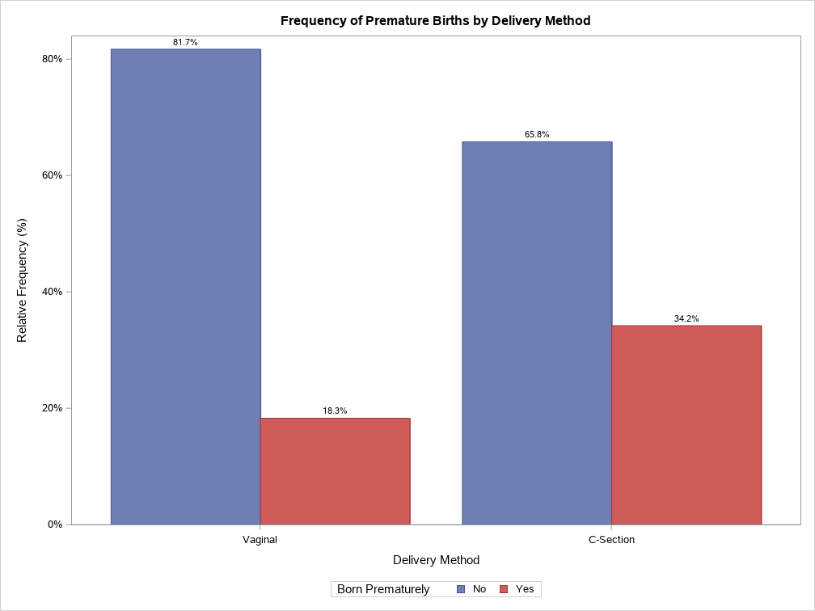

```sas
proc sgplot data = birth pctlevel=group;
    format DMETH_REC dmeth_form. BORN_PRE preemie_form.;
    vbar DMETH_REC / group = BORN_PRE stat=percent groupdisplay=cluster datalabel;
    title1 "Frequency of Premature Births by Delivery Method";
    label BORN_PRE = "Born Prematurely";
    xaxis label="Delivery Method";
    yaxis label="Relative Frequency (%)";
run;
```

Confirming my belief above, premature birth tends to happen much more often when the delivery method is a C-Section. This is due to, confirmed by scientific research, that having an abnormal cervix or uterus can result in a higher risk of a premature birth.

With such a high difference of premature births between delivery methods, I believe that this variable will be highly useful for predicting premature birth.

Moving on from delivery method, I want to look at the **DPLURAL**, which is a categorical variable of the amount of babies born during the pregnancy. Research shows that carrying more than one baby at a time can result in a higher risk of premature birth.

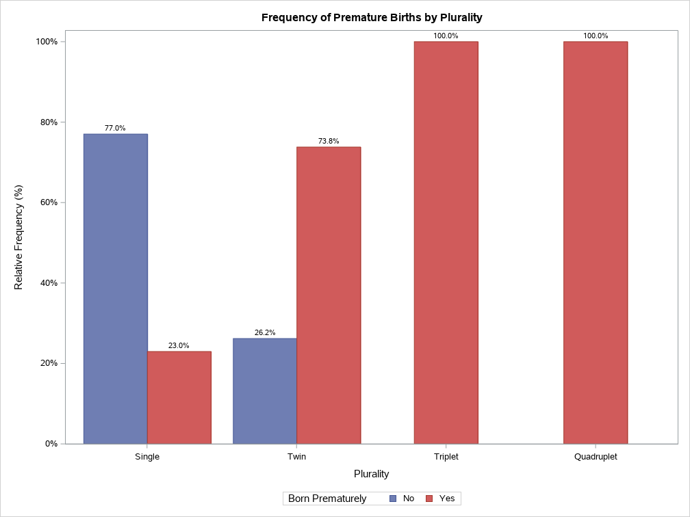

```sas
proc sgplot data = birth pctlevel=group;
    format DPLURAL dplural_form. BORN_PRE preemie_form.;
    vbar DPLURAL / group = BORN_PRE stat=percent groupdisplay=cluster datalabel;
    title1 "Frequency of Premature Births by Plurality";
    label BORN_PRE = "Born Prematurely";
    xaxis label="Plurality";
    yaxis label="Relative Frequency (%)";
run;
```

Babies born with a congenital anomaly have a much, much higher chance of being born prematurely given that they are not a singleton baby.

If born as a singleton, we see that only 23.0% of these babies are born prematurely.

While looking at twins, we see that 73.8% of babies are born prematurely.

Although the triplet and quadruplet categories may be influenced by low observations, we see that 100.0% of these babies are born prematurely.

Overall this plot confirms the research that having twins or more highly increases your risk of giving birth to a premature baby.

**SEX** is the next variable to be analyzed. While I do not believe (nor have I found any research showing evidence) that sex plays a role in risk of being born prematurely, I do think that this variable is interesting to include in the analysis as well as predictive model.

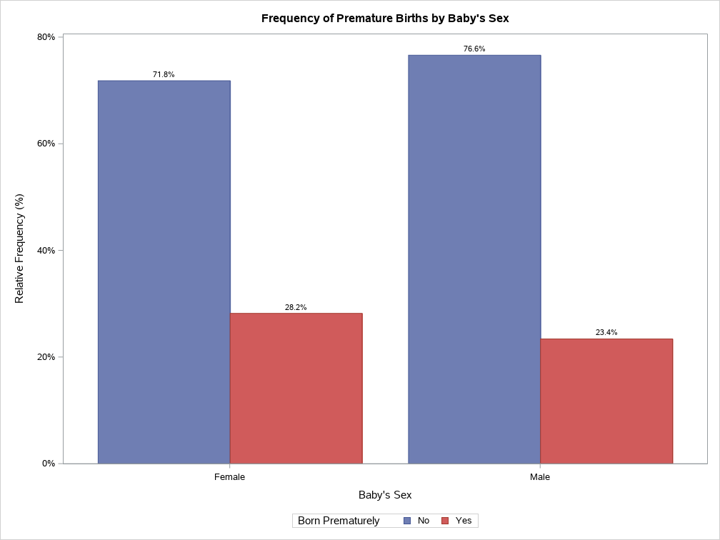

```sas
proc sgplot data = birth pctlevel=group;
    format SEX_BIN sex_form. BORN_PRE preemie_form.;
    vbar SEX_BIN / group = BORN_PRE stat=percent groupdisplay=cluster datalabel;
    title1 "Frequency of Premature Births by Baby's Sex";
    label BORN_PRE = "Born Prematurely";
    xaxis label="Baby's Sex";
    yaxis label="Relative Frequency (%)";
run;
```

As per my belief, there is not much of a difference between female and male's babies chance of being born prematurely. Although it should be noted that some difference is seen, as female baby's have 28.2% of births being premature and male baby's have 23.4% of births being premature.

Using the plot only, it can be said that female baby's have a higher chance of premature birth compared to male baby's. However, I do believe that this difference can be due to data imbalance. To confirm this belief, I will utilize the chi-square test.

```sas
proc freq data=birth;
    tables born_pre*SEX_BIN /chisq;
    ods select ChiSq;
run;
```

The FREQ Procedure

Statistics for Table of BORN_PRE by SEX_BIN

| Statistic | DF | Value | Prob |
| --- | --- | --- | --- |
| Chi-Square | 1 | 30.5082 | <.0001 |
| Likelihood Ratio Chi-Square | 1 | 30.2054 | <.0001 |
| Continuity Adj. Chi-Square | 1 | 30.2542 | <.0001 |
| Mantel-Haenszel Chi-Square | 1 | 30.5053 | <.0001 |
| Phi Coefficient |  | -0.0532 |  |
| Contingency Coefficient |  | 0.0531 |  |
| Cramer's V |  | -0.0532 |  |

Looking at the output above, we can reject $H_0$ that these two variables are independent and conclude that they are associated. However, they are very weakly associated when looking at the Phi Coefficient and other association measures. This variable will be kept in for modeling.

The last categorical variable to be analyzed is the **CIG_BIN** variable. This variable tells the reader whether or not the mother used cigarettes before or during pregnancy. Due to smoking playing a large role in the risk of premature birth, I believe this plot will support this using our given data.

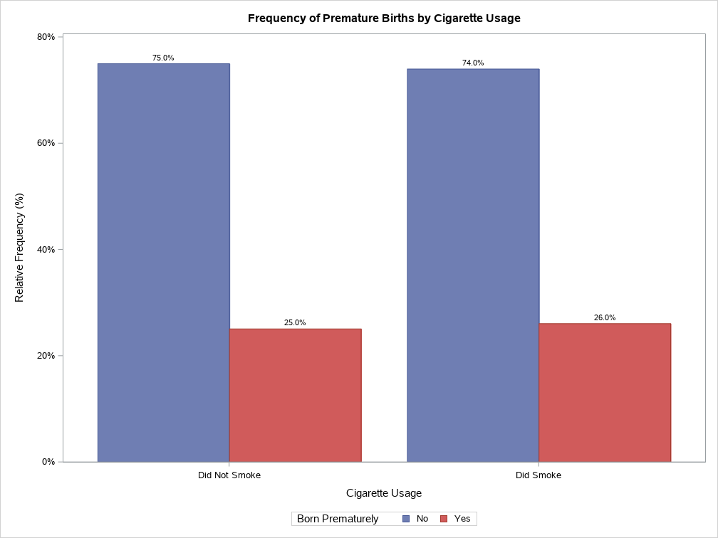

```sas
proc sgplot data = birth pctlevel=group;
    format CIG_BIN cig_form. BORN_PRE preemie_form.;
    vbar CIG_BIN / group = BORN_PRE stat=percent groupdisplay=cluster datalabel;
    title1 "Frequency of Premature Births by Cigarette Usage";
    label BORN_PRE = "Born Prematurely";
    xaxis label="Cigarette Usage";
    yaxis label="Relative Frequency (%)";
run;
title;
```

Oddly, the plot above does not support my claim that cigarette usage will result in a higher risk of premature birth. Those that did not smoke before/during pregancy see a 25.0% chance of premature birth, while those that did smoke before/during pregnancy see a 26.0% chance of premature birth.

Recall that I am only analyzing babies being born with a congenital anomaly, so that can be influencing this plot by smoking contributing more to the anomaly rather than the premature birth.

Also, it should be noted that this variable is considering "Did Smoke" as all mothers who smoked before/during pregancy. Typically, if mothers stop smoking during pregnancy this will not lead to higher risks of premature births. This idea may be influencing the plot, as it does not completely tell the story of if a mother smoked during her pregnancy which is the most important factor.

I will perform a chi-square test for independence to further analyze association.

```sas
proc freq data=birth;
    tables born_pre*CIG_BIN /chisq;
    ods select ChiSq;
run;
```

The FREQ Procedure

Statistics for Table of BORN_PRE by CIG_BIN

| Statistic | DF | Value | Prob |
| --- | --- | --- | --- |
| Chi-Square | 1 | 0.5422 | 0.4615 |
| Likelihood Ratio Chi-Square | 1 | 0.5385 | 0.4630 |
| Continuity Adj. Chi-Square | 1 | 0.4907 | 0.4836 |
| Mantel-Haenszel Chi-Square | 1 | 0.5421 | 0.4615 |
| Phi Coefficient |  | 0.0071 |  |
| Contingency Coefficient |  | 0.0071 |  |
| Cramer's V |  | 0.0071 |  |

Looking at the test output, we overwhelmingly fail to reject $H_0$ that these variables are independent. We also see a very, very weak association when looking at the Phi Coefficient. Once again, this variable will be kept in the original model for automatic selection to determine if it is useful.

Moving forward from categorical variables, I will analyze our last variable which is a numeric variable. This varable is **DBWTLBS**, which is the babies weight in pounds. I will first start with a numerical summary of this variable.

```sas
proc univariate data=birth;
    var DBWTLBS;
    ods select extremeobs basicmeasures moments quantiles;
run;
```

The UNIVARIATE Procedure

Variable: DBWTLBS

| Moments |  |  |  |
| --- | --- | --- | --- |
| N | 10784 | Sum Weights | 10784 |
| Mean | 6.45117726 | Sum Observations | 69569.4956 |
| Std Deviation | 1.74664708 | Variance | 3.05077603 |
| Skewness | -0.6422096 | Kurtosis | 0.60245452 |
| Uncorrected SS | 481701.666 | Corrected SS | 32896.5179 |
| Coeff Variation | 27.074858 | Std Error Mean | 0.01681958 |

| Basic Statistical Measures Location | Basic Statistical Measures Location | Basic Statistical Measures Variability | Basic Statistical Measures Variability |
| --- | --- | --- | --- |
| Mean | 6.451177 | Std Deviation | 1.74665 |
| Median | 6.696035 | Variance | 3.05078 |
| Mode | 7.180617 | Range | 11.93392 |
|  |  | Interquartile Range | 2.18062 |

| Quantiles (Definition 5) Level | Quantiles (Definition 5) Quantile |
| --- | --- |
| 100% Max | 12.43392 |
| 99% | 9.82379 |
| 95% | 8.88767 |
| 90% | 8.42952 |
| 75% Q3 | 7.64317 |
| 50% Median | 6.69604 |
| 25% Q1 | 5.46256 |
| 10% | 4.11894 |
| 5% | 3.17181 |
| 1% | 1.33480 |
| 0% Min | 0.50000 |

| Extreme Observations Lowest Value | Extreme Observations Lowest Obs | Extreme Observations Highest Value | Extreme Observations Highest Obs |
| --- | --- | --- | --- |
| 0.500000 | 8651 | 11.9890 | 1785 |
| 0.500000 | 3159 | 11.9890 | 9947 |
| 0.530837 | 2365 | 12.0595 | 8250 |
| 0.572687 | 4167 | 12.3877 | 2162 |
| 0.583700 | 607 | 12.4339 | 10625 |

Using the output above, we are able to get a complete numerical analysis of this variable.

Our average baby weight is 6.45 pounds, which is about 1.05 pounds less than the known newborn baby average. With a standard deviation of 1.75, about 95% of the babies should fall between 2.95lbs and 9.95lbs assuming normality of this variable. This average and 95% assumed interval tells me that these babies have a lower range than normal, which can be due to the fact that these babies all have a congenital anomaly.

Looking at the quantiles, our max baby weight is 12.43lbs and minimum baby weight is 0.5 pounds. This does not seem too extreme for me, as prematurely born babies weigh much less and 12.43lbs is not an unbelievable weight for a newborn. The median, or 50th percentile, is 6.69 which is extremely close to the mean. The IQR (Q3-Q1) is 2.18, which is quite small and tells me that a good amount of our data lies between 5.46-7.64lbs which is not suprising.

For extreme observations, we see a few babies born at around half a pound. As said before, these are most likely babies that are born prematurely and therefore do not weigh much. We also see a few babies born around 12-12.5lbs, which is not an unbelieveable weight for a newborn.

Overall, from these numerical summaries we are able to get a good idea of this variable and it's outliers/distribution. I now want to continue to look at the distribution using histograms.

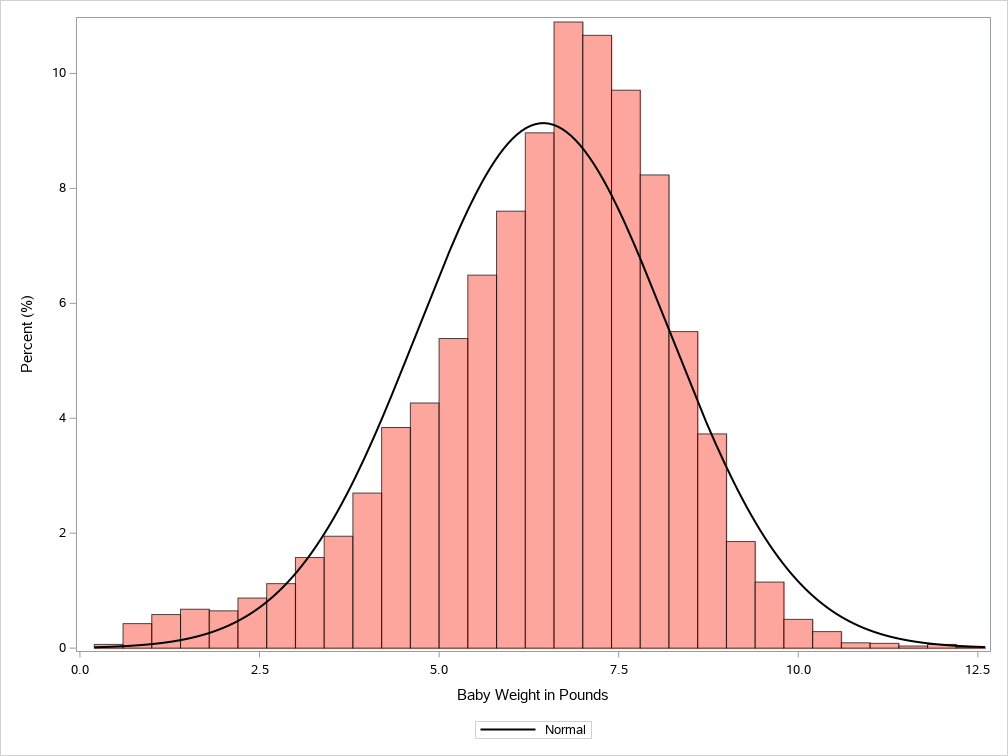

```sas
proc sgplot data=birth;
    histogram dbwtlbs /fillattrs=(color='salmon') transparency=0.3;
    density dbwtlbs / type = normal lineattrs=(color='black');
    xaxis label='Baby Weight in Pounds';
    yaxis label='Percent (%)';
run;
```

Looking at the histogram above, we can see that the variable is somewhat normally distributed however it is quite left skewed. This is due to these babies seemingly having more low birth weights compared to high birth weights. I believe that this is due to these babies having a congenital anomaly, which can cause a lower birth weight. Mentioned above, it does look that ~95% of this data is contained between 2.95lbs and 9.95lbs.

Next, I want to get numerical summaries of this variable between prematurely born babies or not.

```sas
proc means data=birth;
    format born_pre preemie_form.;
    class born_pre;
    var dbwtlbs;
run;
```

The MEANS Procedure

| Analysis Variable : DBWTLBS BORN_PRE | Analysis Variable : DBWTLBS N Obs | Analysis Variable : DBWTLBS N | Analysis Variable : DBWTLBS Mean | Analysis Variable : DBWTLBS Std Dev | Analysis Variable : DBWTLBS Minimum | Analysis Variable : DBWTLBS Maximum |
| --- | --- | --- | --- | --- | --- | --- |
| No | 8072 | 8072 | 7.0834843 | 1.2463991 | 2.0176211 | 12.4339207 |
| Yes | 2712 | 2712 | 4.5691778 | 1.6660692 | 0.5000000 | 10.4273128 |

Looking at the means table above, we can see that 2712 babies were born prematurely and 8072 babies were not. So, ~25% of the data is represented by premature babies which is a good class distribution as it is not extremely low.

The mean baby weight for non-preemie babies is 7.08lbs, which is much more on par with the known average baby weight. Although still lower, which can be due to the congenital anomalies. The minimum baby weight is 2.02lbs, which is much higher than the seen 0.5lbs although still low.

The mean baby weight for preemie babies is 4.57lbs. This is much lower than the known average baby weight. This confirms that prematurely born babies have a much lower weight than non prematurely born babies. Also, as mentioned above, the minimum baby weight of 0.5lbs is from the prematurely born babies.

Prematurely born babies have a standard deviation quite a bit higher, about .4 pounds.

Overall, this grouped summary lets us further understand how a babies weight can change between being born prematurely or not.

I now will look at each groups distribution.

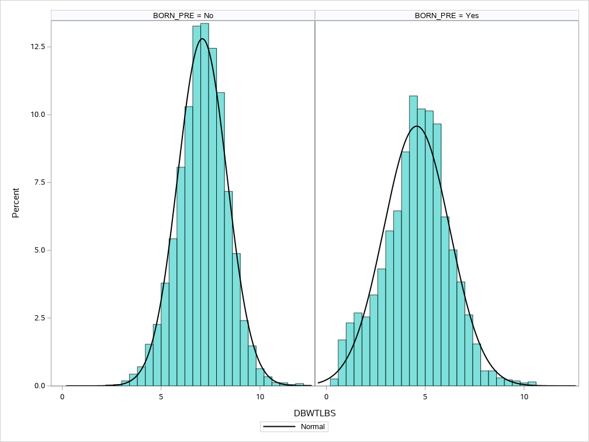

```sas
proc sgpanel data=birth;
    format born_pre preemie_form.;
    panelby born_pre;
    histogram dbwtlbs /fillattrs=(color='CX48D1CC') transparency=0.3;
    density dbwtlbs / type = normal lineattrs=(color='black');
run;
```

Looking at the histograms above, we can see that babies not born prematurely are much more normally distributed than those born prematurely. This is due to prematurely born babies being heavily left skewed due to their potential extreme low weights.

Overall, these histograms further confirm that a baby's weight in pounds plays a large role in whether the baby is born prematurely or not.

Lastly, I want to look at box-plots to determine potential outliers.

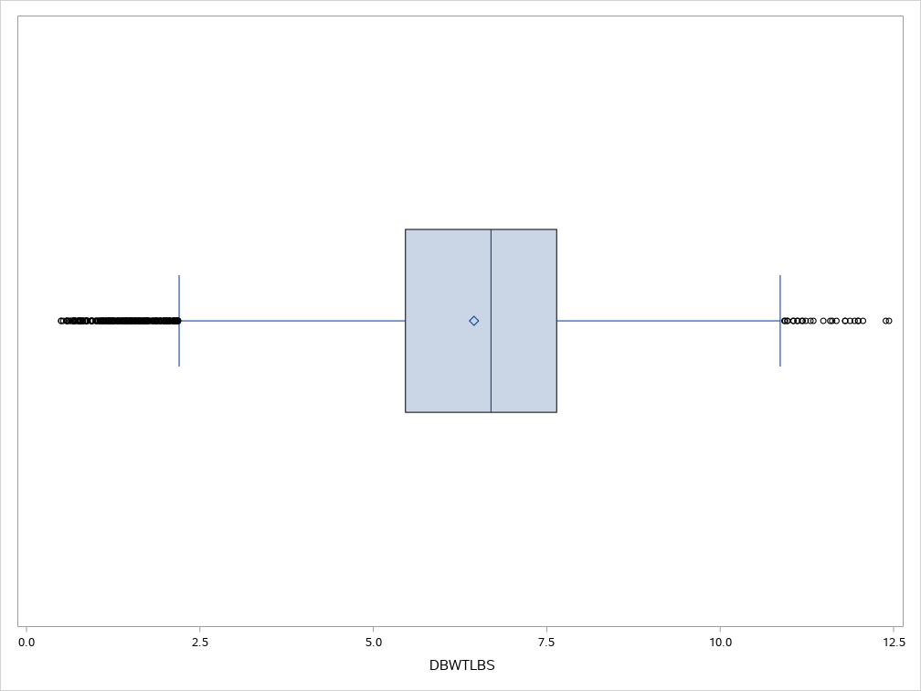

```sas
proc sgplot data=birth;
    hbox dbwtlbs;
run;
```

As noted in the original numerical summary, there are definite outliers in this baby. There are a large amount of babies born under 2.5 pounds, but as seen above mostly come from prematurely born babies where they can have extremely low weights. There are also a few "outliers" that have high weights, but these are realistic baby weights and should not be considered actual outliers.

Lastly, I want to look for outliers between prematurely born baby's or not to further confirm the above statement.

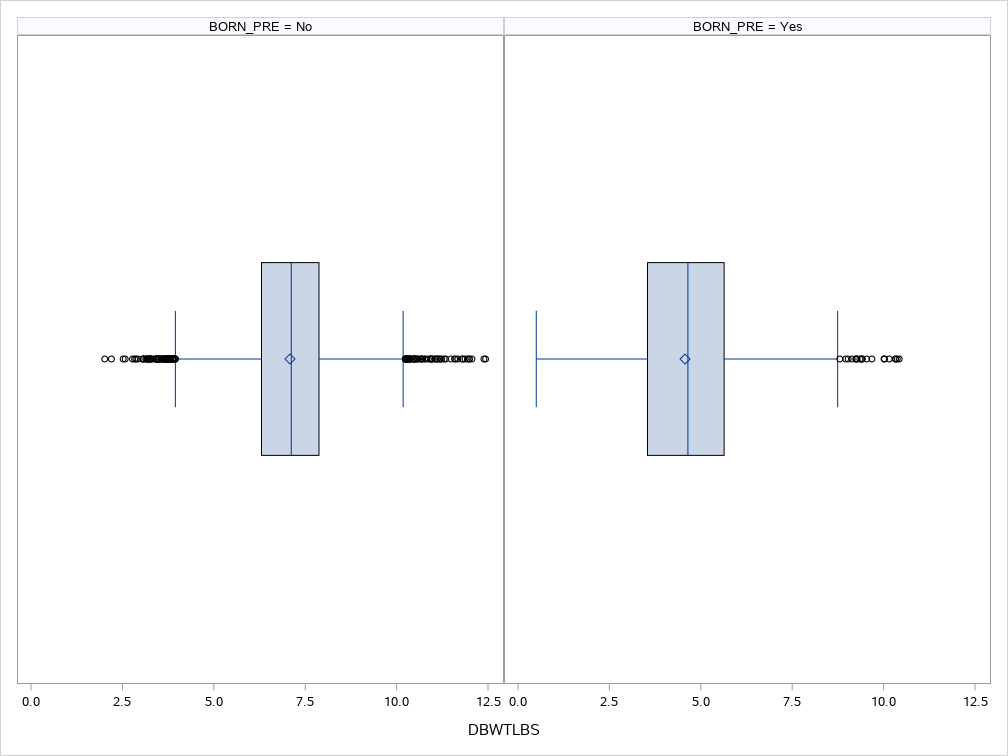

```sas
proc sgpanel data=birth;
    format born_pre preemie_form.;
    panelby born_pre;
    hbox dbwtlbs;
run;
```

Looking at the box-plots above, it can be seen right away that outliers are observed more often in babies not born prematurely. Once again, an outlier in this sense should not be considered an actual outlier as these are still realistic baby weights.

For the prematurely born babies, notice that it is not even considered an outlier if born at the minimum .50 pounds. It is however considered an outlier if born about ~8.5 pounds. This further confirms that prematurely born babies have a much lower birth weight.

It also should be stated that due to the differences in distributions between babies born prematurely or not, we are able to conclude correlation between **DBWTLBS** and **BORN_PRE**.

```sas
proc corr data=birth Spearman;
    var born_pre;
    with dbwtlbs;
    ods select SpearmanCorr;
run;
```

The CORR Procedure

| Spearman Correlation Coefficients, N = 10784 Prob > \|r\| under H0: Rho=0 | Spearman Correlation Coefficients, N = 10784 Prob > \|r\| under H0: Rho=0 BORN_PRE |
| --- | --- |
| DBWTLBS | -0.58892 <.0001 |

Using the spearman correlation coefficient above, I am able to further conclude of a correlation between these two variables. There is a negative association of ~.59, which makes sense to me. As a babies weight increases, there is less of a chance that the baby is born prematurely. With all variables analyzed between groups as well as on their own, I will now move onto the modeling portion of this analysis. I will start off with a logistic regression model, and possibly move forward to a KNN model. In order to verify model accuracy, I will be splitting the data into a training and test set. I will be utilizing stratification in order to maintain almost identical ratios of baby's born prematurely or not in both datasets.

```sas
data temp;
    set birth;
    n = ranuni(8173);
run;
proc sort data=temp;
    by born_pre n;
run;

data birthtrn birthtst;
    set temp;
    if mod(_n_, 3) = 0 or mod(_n_, 3) = 2
        then output birthtrn;
    else output birthtst;
run;
```

[output not shown]

With the training data, I can now build the logistic regression model.

```sas
proc print data=birthtrn(obs=2);
run;
```

| Obs | MAGER14 | MBSTATE_REC | MRACE6 | PRECARE5 | PREVIS_REC | BMI_R | DMETH_REC | DPLURAL | SEX_BIN | CIG_BIN | BORN_PRE | DBWTLBS | n |
| --- | --- | --- | --- | --- | --- | --- | --- | --- | --- | --- | --- | --- | --- |
| 1 | 11 | 1 | 1 | 1 | 5 | 2 | 2 | 1 | 1 | 0 | 0 | 7.68722 | .000569385 |
| 2 | 7 | 1 | 1 | 1 | 9 | 2 | 2 | 1 | 0 | 0 | 0 | 7.00441 | .000688955 |

```sas
proc logistic data=birthtrn;
 class mager14 mbstate_rec mrace6 precare5
       previs_rec bmi_r dmeth_rec dplural sex_bin cig_bin / param=ref ref=first;
 model born_pre(event="1") = mager14 mbstate_rec mrace6 precare5 previs_rec
                               bmi_r dmeth_rec dplural sex_bin cig_bin dbwtlbs
                               / selection=forward sle=0.05;
 output out=log_trn_preds predprobs=individual;
 score data=birthtst out=log_tst_preds;
 ods select modelbuildingsummary;
run;
```

The LOGISTIC Procedure

| Summary of Forward Selection Step | Summary of Forward Selection Effect Entered | Summary of Forward Selection DF | Summary of Forward Selection Number In | Summary of Forward Selection Score Chi-Square | Summary of Forward Selection Pr > ChiSq |
| --- | --- | --- | --- | --- | --- |
| 1 | DBWTLBS | 1 | 1 | 2805.9497 | <.0001 |
| 2 | DMETH_REC | 1 | 2 | 46.4298 | <.0001 |
| 3 | PREVIS_REC | 10 | 3 | 76.6334 | <.0001 |
| 4 | PRECARE5 | 2 | 4 | 35.7595 | <.0001 |
| 5 | DPLURAL | 3 | 5 | 35.1675 | <.0001 |
| 6 | SEX_BIN | 1 | 6 | 8.3225 | 0.0039 |
| 7 | MBSTATE_REC | 1 | 7 | 8.0731 | 0.0045 |
| 8 | CIG_BIN | 1 | 8 | 8.7967 | 0.0030 |
| 9 | BMI_R | 5 | 9 | 13.6476 | 0.0180 |

I want to first evaluate this model on the training procedure to see how it performs on seen data.

```sas
proc format;
    value $preemie_pred_form '1' = 'Yes'
                            '0' = 'No';
run;
proc sort data=log_trn_preds;
    by descending born_pre descending _INTO_;
run;
title 'Confusion Matrix on Training Data';
proc freq data=log_trn_preds;
    format _INTO_ $preemie_pred_form. born_pre preemie_form.;
    table _INTO_*born_pre / out=log_confmat;
run;
title;
data log_confmat;
    set log_confmat;
    match = 0;
    if born_pre = _INTO_ then match = 1; /*for computing accuracy rate*/
run;
title 'Accuracy Rate on Training Data';
proc means data=log_confmat mean;
    freq count;
    var match;
run;
title;
```

Confusion Matrix on Training Data

The FREQ Procedure

| Frequency Percent Row Pct Col Pct |
| --- |

| Table of _INTO_ by BORN_PRE _INTO_(Formatted Value of the Predicted Response) | Table of _INTO_ by BORN_PRE BORN_PRE No | Table of _INTO_ by BORN_PRE BORN_PRE Yes | Table of _INTO_ by BORN_PRE BORN_PRE Total |
| --- | --- | --- | --- |
| No | 5071 70.54 88.01 94.24 | 691 9.61 11.99 38.22 | 5762 80.15 |
| Yes | 310 4.31 21.72 5.76 | 1117 15.54 78.28 61.78 | 1427 19.85 |
| Total | 5381 74.85 | 1808 25.15 | 7189 100.00 |

Accuracy Rate on Training Data

The MEANS Procedure

| Analysis Variable : match Mean |
| --- |
| 0.8607595 |

Using the above output, we obtain a mean accuracy rate of .8608 on the training data for predicting whether a baby is born prematurely or not given some factors. This is pretty good, but most definitely has room for improvement. Also, this is obtained on the training dataset so test accuracy could be much lower.

Looking at the confusion matrix on the training data, we see that we are correctly predicting true 'No' values 94.24% of the time, and mispredicting 'Yes' on true 'No' values 5.76% of the time. This is quite good, and shows that are model does very well for classifying that a baby will not be born prematurely. For classifying that a baby will be born prematurely, or 'Yes', we are only correctly classifying 61.78% of true premature births. This means that we are misclassifying the other 38.22% of the premature births as non-premature births! This is no good, and shows that our model is not performing well on the original goal of classifying premature births.